# Biostat M280 Homework 3

Due Mar 1 @ 11:59PM

Edward Yu

Use tidyverse and bash to explore following two data sets.

## Q1 LA City Employee Payroll

The `/home/m280data/la_payroll/City_Employee_Payroll.csv` file on teaching server contains payroll information of LA City employees in years 2013-2018. It was downloaded from [LA City Controller’s Office](https://controllerdata.lacity.org/Payroll/City-Employee-Payroll/pazn-qyym). Make a Shiny app to facilitate visualization of this data.

1. For efficiency of the Shiny app, you should first pre-process, pare down, tidy, and save the data, e.g., as a compressed RDS file, to be used in the app.
2. **Total payroll by LA City**. Visualize the total LA City payroll of each year, with breakdown into base pay, overtime pay, and other pay.
3. **Who earned most?** Visualize the payroll information (total payment with breakdown into base pay, overtime pay, and other pay, Department, Job Title) of the top $n$ highest paid LA City employees in a specific year. User specifies $n$ (default 10) and year (default 2017).
4. **Which departments earn most?** Visualize the mean or median payroll, with breakdown into base pay, overtime pay, and other pay, of top $n$ earning departments. User specifies $n$ (default 5), year (default 2017), and method (mean or median, default median).
5. **Which departments cost most?** Visualize the total payroll, with breakdown into base pay, overtime pay, and other pay, of top $n$ expensive departments. User specifies $n$ (default 5) and year (default 2017).
6. Visualize any other information you are interested in.
7. Publish your Shiny app to https://www.shinyapps.io and share the link.

**Solution**: Below is a link to my shiny new app: https://edwardmjyu.shinyapps.io/lapayroll_shiny/

## Q2 LA City Parking War

The SQLite database `/home/m280data/la_parking/LA_Parking_Citations.sqlite` on teaching server contains information about parking tickets in LA City. It was downloaded from [LA Open Data Portal](https://data.lacity.org/A-Well-Run-City/Parking-Citations/wjz9-h9np). Connect to the database and answer following questions using plots and summary statistics. In this exercise, you are **not** allowed to load whole data into memory. Use the *transform in database, plot in R* strategy.

```r
### Initiate Libraries ###
library("DBI")
library("RSQLite")
library("tidyverse")
### Prepare SQL Connection ###
con <- dbConnect(RSQLite::SQLite(),
                "/home/m280data/la_parking/LA_Parking_Citations.sqlite")
dbListTables(con) #Check tables available in connection
latix <- dplyr::tbl(con, "latix")
knitr::opts_chunk$set(connection = "con")
```

**1. How many tickets are in this data set? Which time period do these tickets span? Which years have most data?**

```sql
SELECT count(DISTINCT Ticket_number) AS num_ticket FROM latix;
```

1 records

| num_ticket |
| --- |
| 7656362 |

**Solution**: There are 7,656,362 distinct tickets, SQL removes any `NA` data.

```sql
SELECT datetime(MIN(Issue_DateTime), 'unixepoch') AS "Start Time",
       datetime(MAX(Issue_DateTime), 'unixepoch') AS "End Time"
FROM latix;
```

1 records

| Start Time | End Time |
| --- | --- |
| 2015-07-02 01:00:00 | 2019-01-25 23:58:00 |

**Solution**: The time period the tickets span is from `2015-07-02 01:00:00 UTC` to `2019-01-25 23:58:00 UTC`.

```sql
SELECT
  strftime('%Y', datetime(Issue_DateTime, 'unixepoch')) AS Year,
  count(*) AS Count
FROM latix
GROUP BY 1
ORDER BY 2 DESC
```

6 records

| Year | Count |
| --- | --- |
| 2017 | 2235243 |
| 2016 | 2177956 |
| 2018 | 1976451 |
| 2015 | 1068245 |
| 2019 | 124458 |
| NA | 74065 |

**Solution**: The year with the most tickets was in 2017 with `2,235,243` tickets.

**2. When (which hour, weekday, month day, and month) are you most likely to get a ticket and when are you least likely to get a ticket?**

Calculating for hour:

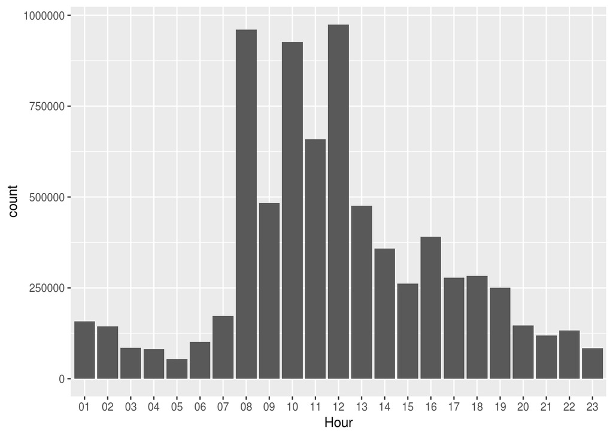

```r
hour <-
  "SELECT
    strftime('%H', DATETIME(Issue_DateTime, 'unixepoch')) AS Hour
  FROM latix
  WHERE Issue_DateTime IS NOT NULL"

hour <- dbGetQuery(con, hour)
ggplot(hour, aes(Hour)) + geom_bar()
```

```r
latix %>%
  select(Issue_Hour) %>%
  filter(!is.na(Issue_Hour)) %>%
  group_by(Issue_Hour) %>%
  summarise(n = n()) %>%
  arrange(desc(n))
```

```
## # Source:     lazy query [?? x 2]
## # Database:   sqlite 3.22.0
## #   [/home/m280data/la_parking/LA_Parking_Citations.sqlite]
## # Ordered by: desc(n)
##    Issue_Hour      n
##         <int>  <int>
##  1         12 975063
##  2          8 960681
##  3         10 926833
##  4         11 659135
##  5          9 483991
##  6         13 475803
##  7         16 391378
##  8         14 358569
##  9         18 282714
## 10         17 278130
## # ... with more rows
```

**Solution**: The bar chart above shows that `12pm` is the most likely time to receive a ticket while `5am` is the least likely time.

Calculating for weekday:

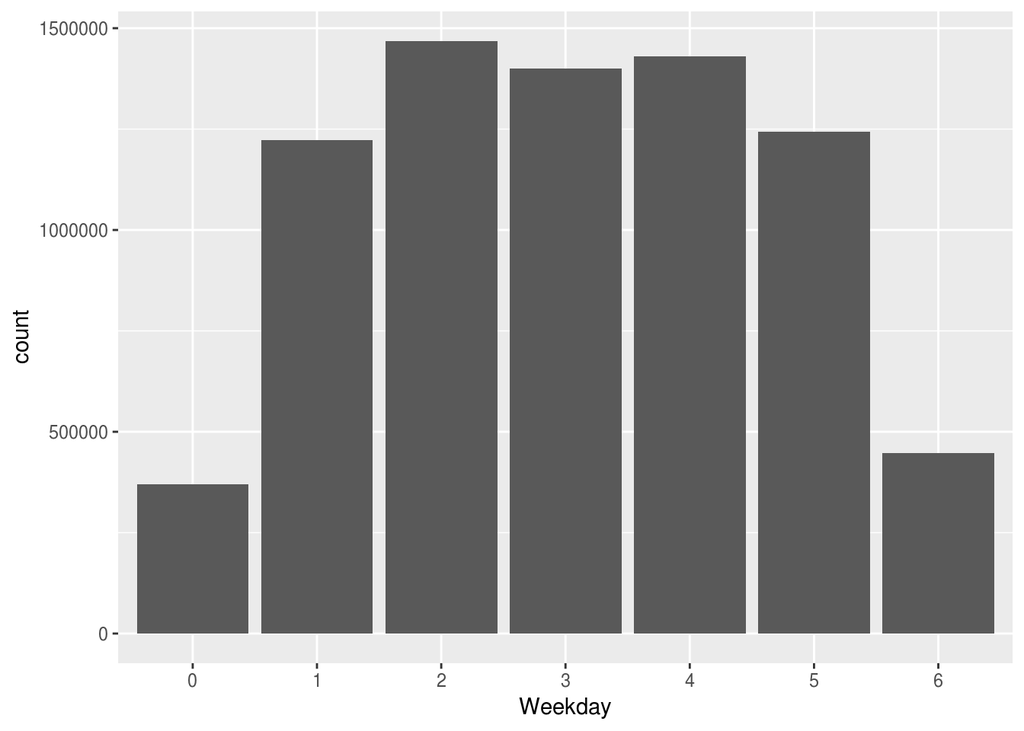

```r
weekday <-
  "SELECT
    strftime('%w', DATETIME(Issue_DateTime, 'unixepoch')) AS Weekday
  FROM latix
  WHERE Issue_DateTime IS NOT NULL"

weekday <- dbGetQuery(con, weekday)
ggplot(weekday, aes(Weekday)) + geom_bar()
```

```r
latix %>%
  select(Issue_Wday) %>%
  filter(!is.na(Issue_Wday)) %>%
  group_by(Issue_Wday) %>%
  summarise(n = n()) %>%
  arrange(desc(n))
```

```
## # Source:     lazy query [?? x 2]
## # Database:   sqlite 3.22.0
## #   [/home/m280data/la_parking/LA_Parking_Citations.sqlite]
## # Ordered by: desc(n)
##   Issue_Wday       n
##        <dbl>   <int>
## 1          3 1468900
## 2          5 1430433
## 3          4 1400552
## 4          6 1243156
## 5          2 1222875
## 6          7  446873
## 7          1  369564
```

Calculating for day of month:

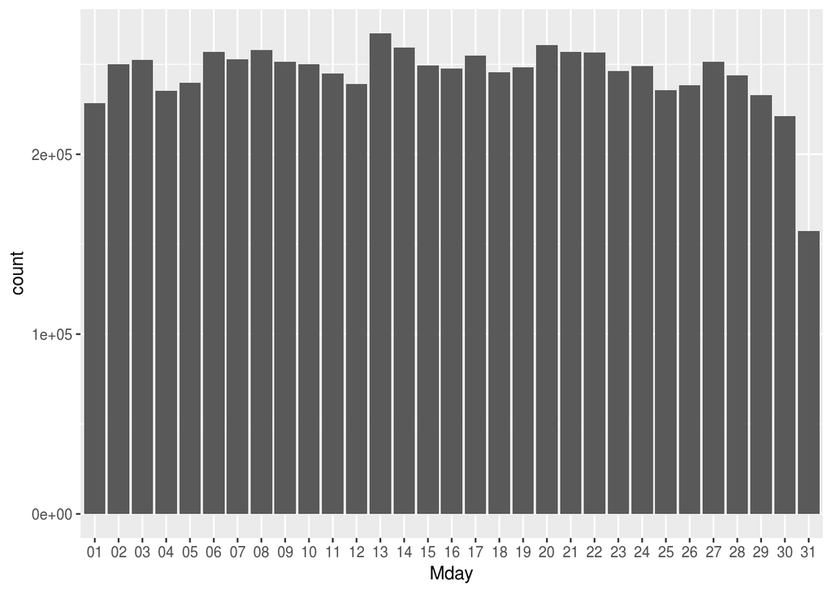

```r
dmonth <-
  "SELECT
    strftime('%d', DATETIME(Issue_DateTime, 'unixepoch')) AS Mday
  FROM latix
  WHERE Issue_DateTime IS NOT NULL"

mday <- dbGetQuery(con, dmonth)
ggplot(mday, aes(Mday)) + geom_bar()
```

```r
latix %>%
  select(Issue_Day) %>%
  filter(!is.na(Issue_Day)) %>%
  group_by(Issue_Day) %>%
  summarise(n = n()) %>%
  arrange(desc(n))
```

```
## # Source:     lazy query [?? x 2]
## # Database:   sqlite 3.22.0
## #   [/home/m280data/la_parking/LA_Parking_Citations.sqlite]
## # Ordered by: desc(n)
##    Issue_Day      n
##        <int>  <int>
##  1        13 267419
##  2        20 260806
##  3        14 259383
##  4         8 257887
##  5         6 256905
##  6        21 256892
##  7        22 256758
##  8        17 254968
##  9         7 252678
## 10         3 252363
## # ... with more rows
```

**Solution**: The bar chart shows that it most likely to get a ticket on day `13` and least likely to get a ticket on day `31`. This is most likely due to there being the least number of months with `31` days.

Calculating for month:

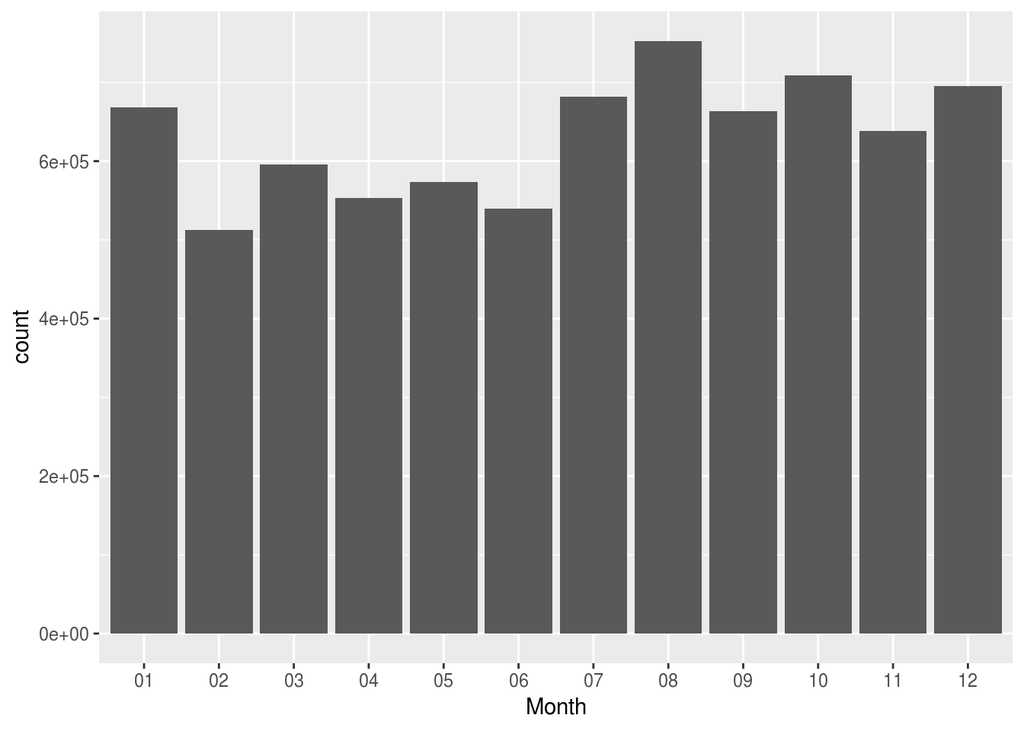

```r
month <-
  "SELECT
    strftime('%m', DATETIME(Issue_DateTime, 'unixepoch')) AS Month
  FROM latix
  WHERE Issue_DateTime IS NOT NULL"

month <- dbGetQuery(con, month)
ggplot(month, aes(Month)) + geom_bar()
```

```r
latix %>%
  select(Issue_Month) %>%
  filter(!is.na(Issue_Month)) %>%
  group_by(Issue_Month) %>%
  summarise(n = n()) %>%
  arrange(desc(n))
```

```
## # Source:     lazy query [?? x 2]
## # Database:   sqlite 3.22.0
## #   [/home/m280data/la_parking/LA_Parking_Citations.sqlite]
## # Ordered by: desc(n)
##    Issue_Month      n
##          <int>  <int>
##  1           8 752904
##  2          10 708922
##  3          12 694987
##  4           7 681518
##  5           1 668404
##  6           9 663592
##  7          11 637852
##  8           3 595775
##  9           5 573197
## 10           4 553417
## # ... with more rows
```

**Solution**: The bar chart shows that it most likely to get a ticket in `August` and least likely to get a ticket in `February`. This is most likely due to there being the least days in `February`.

**3. Which car makes received most citations?**

```r
car <-
 "SELECT
    Make AS Car,
    COUNT(*) AS Number
  FROM latix
  WHERE Make IS NOT NULL
  GROUP BY 1
  ORDER BY 2 DESC
  LIMIT 1"

dbGetQuery(con, car)
```

```
##    Car  Number
## 1 TOYT 1270804
```

**Solution**: The make that received the most citations was Toyota with a total of `1,270,804` citations.

**4. How many different colors of cars were ticketed? Which color attracted most tickets?**

```r
color <-
 "SELECT
    Color AS Color,
    COUNT(*) AS Number
  FROM latix
  WHERE Color IS NOT NULL
  GROUP BY 1
  ORDER BY 2 DESC
  LIMIT 1"

color <- dbGetQuery(con, color)
c(color[1,],nrow(color))
```

```
## $Color
## [1] "BK"
##
## $Number
## [1] 1652621
##
## [[3]]
## [1] 1
```

**5. What are the most common ticket types?**

```r
ticket_type <-
 "SELECT
    Violation_Description AS violation,
    COUNT(*) AS Number
  FROM latix
  WHERE violation IS NOT NULL
  GROUP BY 1
  ORDER BY 2 DESC
  LIMIT 1"

dbGetQuery(con, ticket_type)
```

```
##              violation  Number
## 1 NO PARK/STREET CLEAN 2234699
```

**Solution**: The most type of ticket is `NO PARK/STREET CLEAN` with `2,234,699` tickets.

**6. How much money was collected on parking tickets in 2016, 2017 and 2018?**

```r
money <-
  "SELECT
    strftime('%Y', DATETIME(Issue_DateTime, 'unixepoch')) AS Year,
    SUM(Fine_amount) AS money
  FROM latix
  WHERE Issue_DateTime IS NOT NULL
  GROUP BY 1"

money <- dbGetQuery(con, money)
money %>%
  filter(Year %in% c("2016", "2017", "2018"))
```

```
##   Year     money
## 1 2016 152145538
## 2 2017 157122489
## 3 2018 138875787
```

**Solution**: The amount of money collected in tickets for the following years: 1. 2016: `$152,145,538` 2. 2017: `$157,122,489` 3. 2018: `$138,875,787`

**7. If you’ve been ticketed in LA County, did you find your ticket in this data set?**

I’ve never been ticketed in LA before!